# Bike Share data reveiw by Tyler Eller

```
##   X.1       X          Start.Time            End.Time Trip.Duration
## 1   1 5688089 2017-06-11 14:55:05 2017-06-11 15:08:21     13.250000
## 2   2 4096714 2017-05-11 15:30:11 2017-05-11 15:41:43     11.533333
## 3   3 2173887 2017-03-29 13:26:26 2017-03-29 13:48:31     22.083333
## 4   4 3945638 2017-05-08 19:47:18 2017-05-08 19:59:01     11.716667
## 5   5 6208972 2017-06-21 07:49:16 2017-06-21 07:54:46      5.483333
##             Start.Station            End.Station  User.Type Gender Age city
## 1 Suffolk St & Stanton St W Broadway & Spring St Subscriber   Male  22   ny
## 2 Lexington Ave & E 63 St        1 Ave & E 78 St Subscriber   Male  39   ny
## 3       1 Pl & Clinton St   Henry St & Degraw St Subscriber   Male  33   ny
## 4   Barrow St & Hudson St        W 20 St & 8 Ave Subscriber Female  34   ny
## 5         1 Ave & E 44 St        E 53 St & 3 Ave Subscriber   Male  28   ny
```

# Univariate Plots Section

Introduction: This data reviews data provided by Motivate about the bike-sharing system in New York, Washington D.C, and Chicago. We will mainly be focusing on the customer in this data set.

let’s take a look at the structure of the data.

```
## 'data.frame':    900000 obs. of  11 variables:
##  $ X.1          : int  1 2 3 4 5 6 7 8 9 10 ...
##  $ X            : int  5688089 4096714 2173887 3945638 6208972 1285652 1675753 1692245 2271331 1558339 ...
##  $ Start.Time   : chr  "2017-06-11 14:55:05" "2017-05-11 15:30:11" "2017-03-29 13:26:26" "2017-05-08 19:47:18" ...
##  $ End.Time     : chr  "2017-06-11 15:08:21" "2017-05-11 15:41:43" "2017-03-29 13:48:31" "2017-05-08 19:59:01" ...
##  $ Trip.Duration: num  13.25 11.53 22.08 11.72 5.48 ...
##  $ Start.Station: chr  "Suffolk St & Stanton St" "Lexington Ave & E 63 St" "1 Pl & Clinton St" "Barrow St & Hudson St" ...
##  $ End.Station  : chr  "W Broadway & Spring St" "1 Ave & E 78 St" "Henry St & Degraw St" "W 20 St & 8 Ave" ...
##  $ User.Type    : chr  "Subscriber" "Subscriber" "Subscriber" "Subscriber" ...
##  $ Gender       : chr  "Male" "Male" "Male" "Female" ...
##  $ Age          : int  22 39 33 34 28 34 38 36 NA 28 ...
##  $ city         : chr  "ny" "ny" "ny" "ny" ...
```

### Gender Breakdown

```
##
## Female   Male
## 124541 385198
```

### Gender Breakdown by Percentage

```
##
## Female   Male
##  20.76  64.20
```

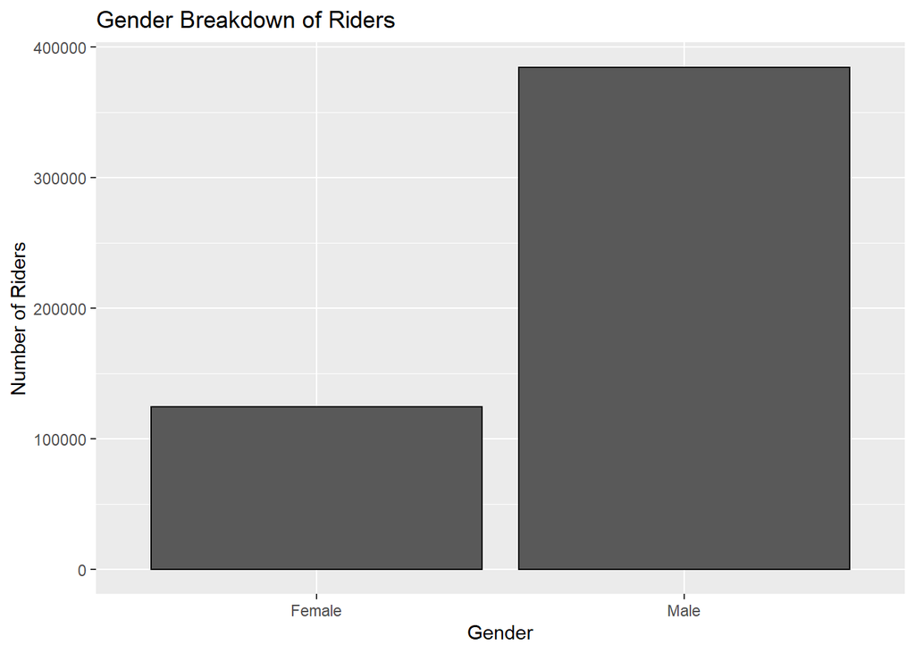

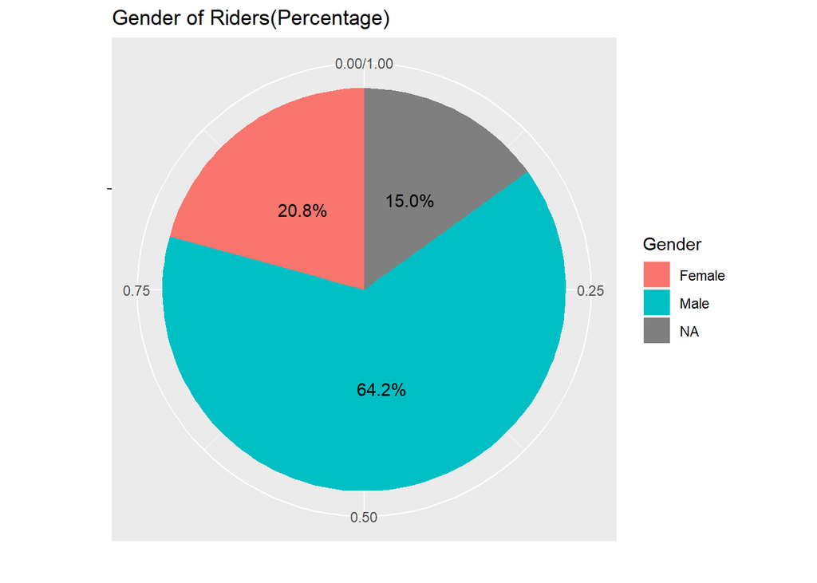

We can now see truly how many more males there are compared to females or people who did not proclaim male or female. Males make up 64.2% of the over all user base.

### Age

What is the most common age of riders? Is there a pattern of usage?

```
##
##    31    32    30    33    34    29    35    36    28    37    38    39    27
## 25792 23440 23187 22778 22557 22239 21381 20852 19542 18328 17277 15762 15307
##    40    41    42    43    44    46    50    45    51    26    49    48    47
## 14394 12261 11450 11082 10296  9710  9612  9405  8939  8776  8640  8539  8483
##    52    54    56    55    53    58    57    60    59    61    62    25    63
##  8161  7370  7300  7154  6987  6949  6704  6405  5694  5005  4366  4210  3983
##    64    24    65    66    23    67    68    69    22    70    71    21    74
##  3549  3191  3084  2786  2600  2477  2121  1655  1477  1205  1204   802   692
##    72    73    20    75    76    78    79    77    80    81    82    86    19
##   684   583   464   374   275   242   162   127   120    62    62    57    55
##   102   120    99   121   119    84    88    83   135    94   127   108   110
##    47    46    33    27    22    16    16    14    13    10     8     7     7
##   114     4    85    97   103   104    87    89    90    92    93    17    18
##     7     6     6     6     5     5     4     4     4     3     3     2     2
##   107   111   125   134    16   113   132
##     2     2     2     2     1     1     1
```

Here you can see that the top five users are in their early 30’s and that a large part of their user base is in their early 30’s. Also, I’m assuming that a few of their outlets are incorrect or fabrication, such the people at 134.

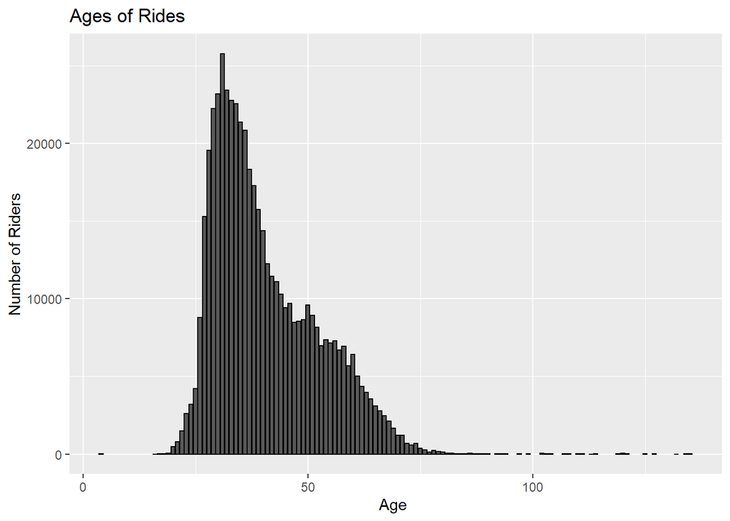

The above graph seems to be stretched out by outlines. Lets scale down to 20-60 to see if the data is better.

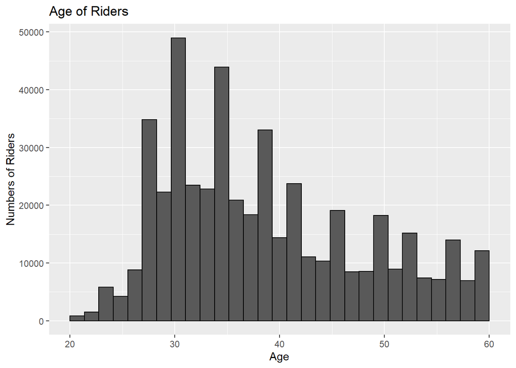

Here you can see that the highest amount of users are in their early 30’s I do find the random spikes in their 50’s and 60’s to be interesting and would love to delve into what causes them.

### User types

let’s take a quick look at the diffrent type of users.

```
##    User.Type      n
## 1   Customer 170483
## 2  Dependent      1
## 3 Subscriber 728824
## 4       <NA>    692
```

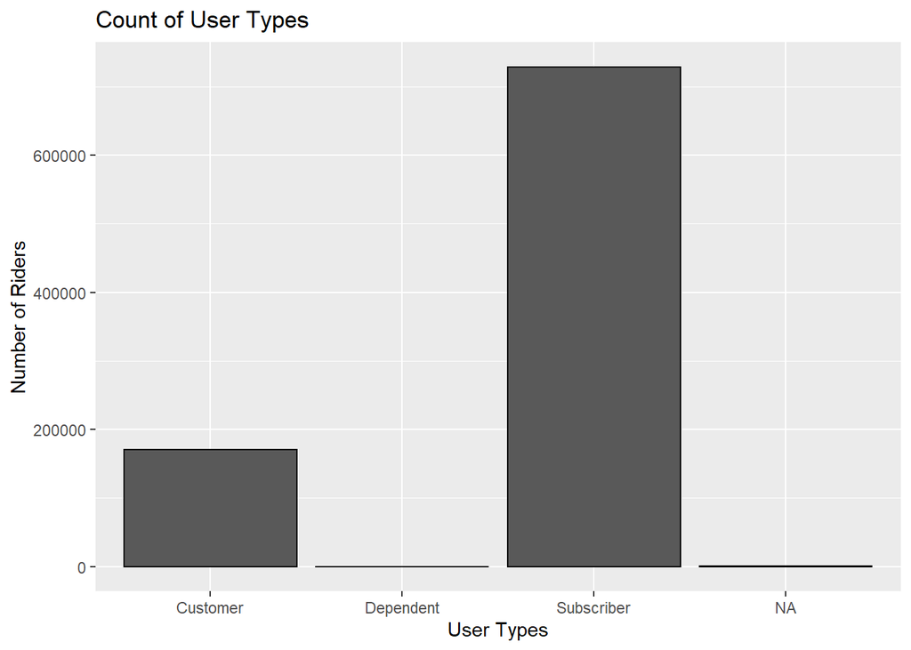

Just as with Gender, there is a definitve majority with Subscriber.

But just as with the Gender, a count is hard to tell the true meaning of the size diffrence, so let’s lookk at the percentage.

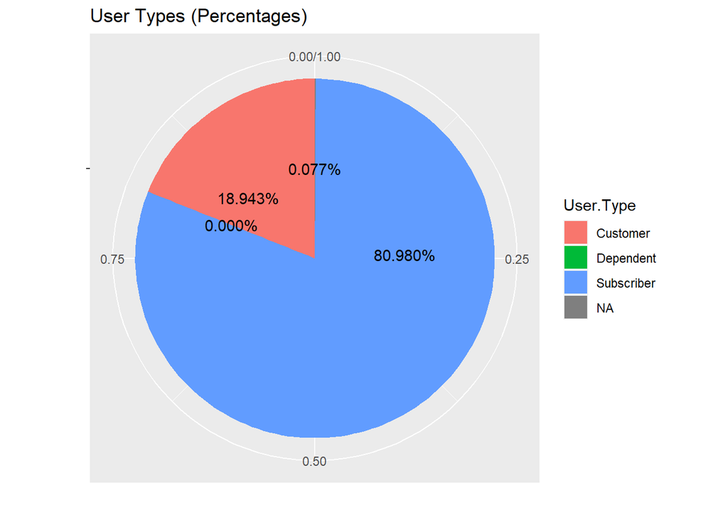

Subscriber is by far the most common type of user with 81% (rounded up).

```
##     Min.  1st Qu.   Median     Mean  3rd Qu.     Max.
##     1.00     6.48    11.00    17.07    18.92 35929.58
```

The average durations of a trip is 17 min.

# Univariate Analysis

### What is/are the main feature(s) of interest in your dataset?

I found the age and gender data to be interesting. This data could be analyzed. This data could help better understand Motivate customer base.

### What other features in the dataset do you think will help support your

###investigation into your feature(s) of interest?

I think delving into the users’ stats by the city could be interesting. If one city has a higher customer count that is female you could explore why that is and see if you could increase the number of female users in other cities.

### Did you create any new variables from existing variables in the dataset?

Yes, I made the Age category as it was easier to read than just looking at the birth_year type.

### Of the features you investigated, were there any unusual distributions?

###Did you perform any operations on the data to tidy, adjust, or change the form  
###of the data? If so, why did you do this?

No, this data was pretty clean and did not need any wrangling. wrangling

# Bivariate Plots Section

Earlier, we took a look at genders for all cites, now let’s take a look at at Genders broken down by city

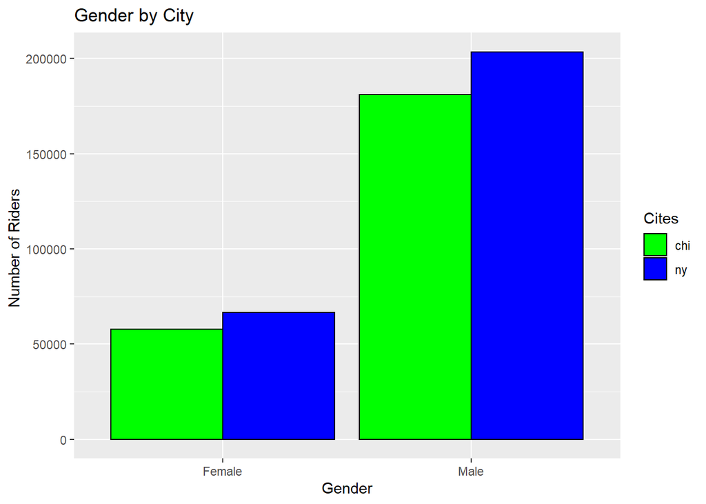

We are only able to see Chicago and New York as Washington does not provided gender data. The service seems more popular in New York then in Chicago, for both genders.

Lets look at gender and age.

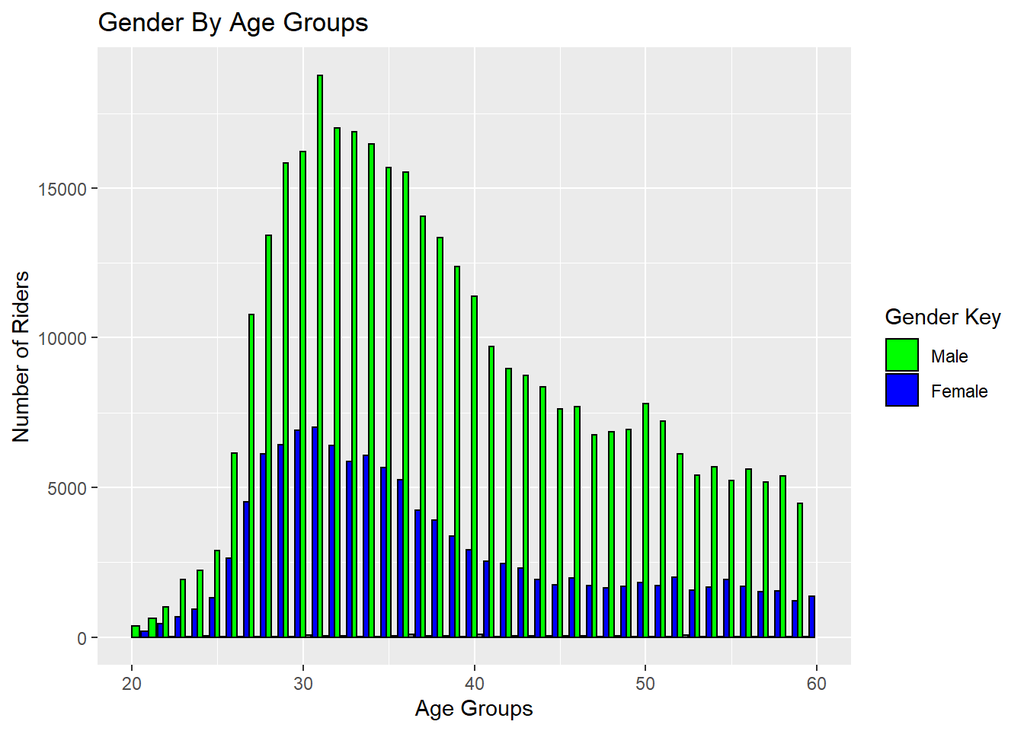

This chart shows the gap between male and email users. Female users in their early 20’s seem to be the closest to their male counterpart. If I was designing a business strategy proposal around this data, I would suggest a campaign to get more young female riders as they seem the most interested and have the opportunity to stay the longest with the service.

As Males are so much more than females, it’s hard to tell they are True count. Let’s dive down into the data and look at females only.

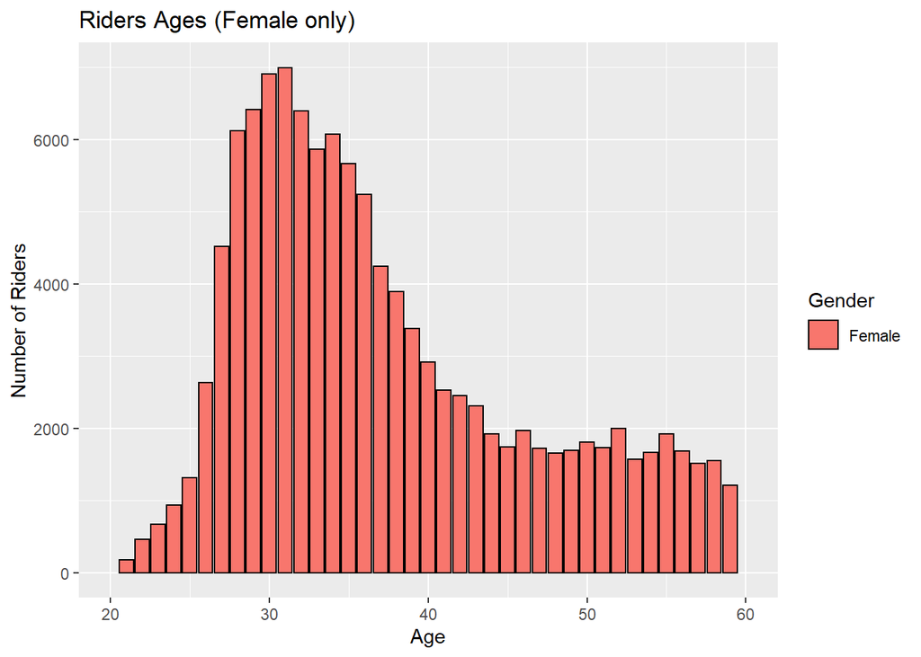

While the number of male customers outweighs the number of female users, I find it interesting that they have the same shape. I wonder if the bike share service does have many under 25 users, and most are over the age of 30 due to income overage. It may be that at 30, people start having enough income to use on extra survives for leisure items. Another data point I’d love to delve into is the reason for use, looking at lessor or transportation.

Just to compaire lets look at the male only table.

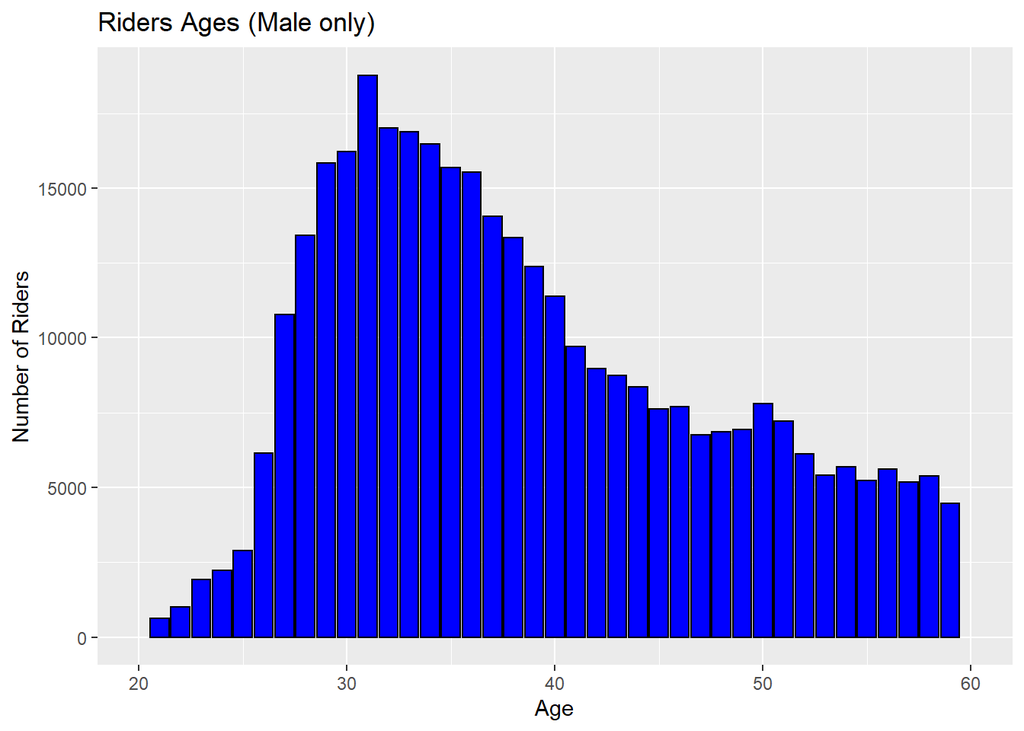

Males in their early 30’s is the largest demographic for this service.

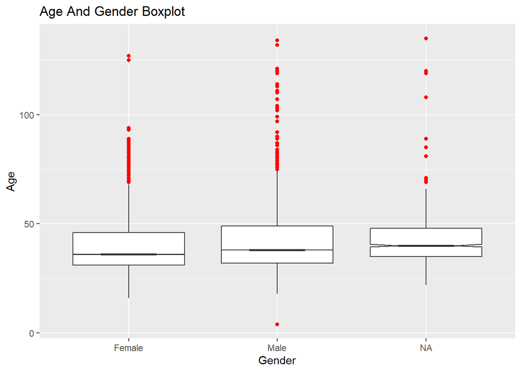

The above box plot aluded to an interesting point the other parts didn’t that Males, seem to have just a slightly older user base going into their 50’s.

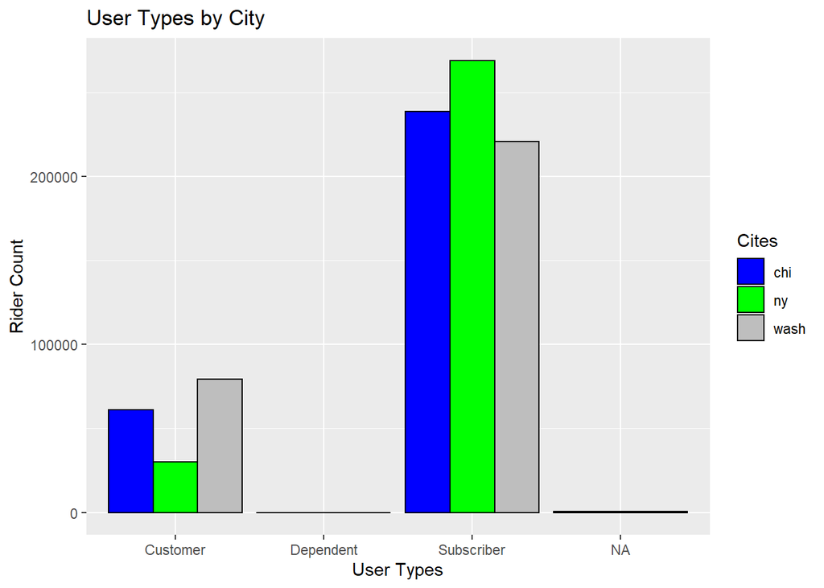

Washington has the most customer type of users. While New York has a strong subscriber.

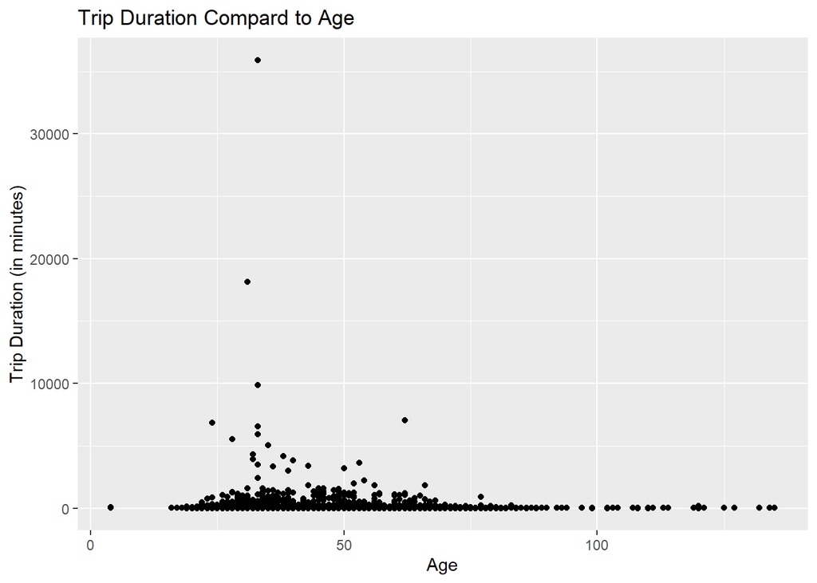

Due to the outlines this graph does not really help us learn anything. Let’s zoom in a little to see if we get a better understanding of the data.

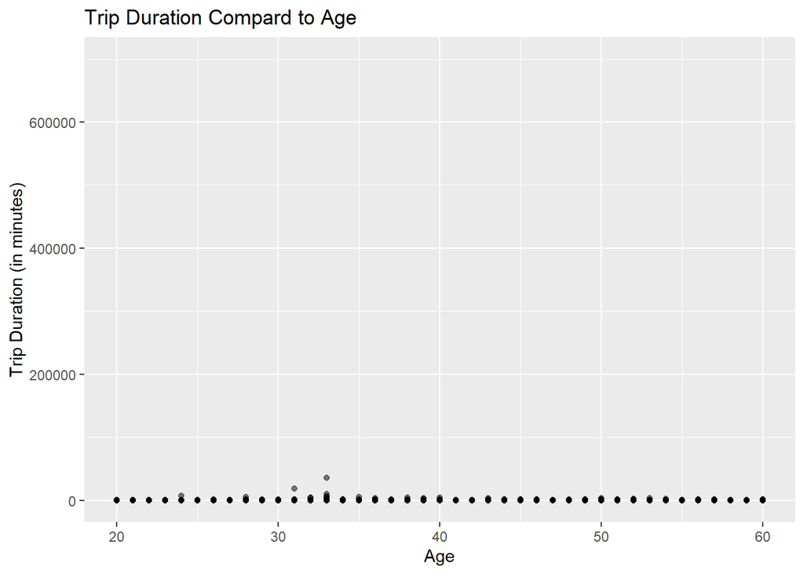

Hmm, this really tells less about the avrage users. Let’s zoom in on the Y acess.

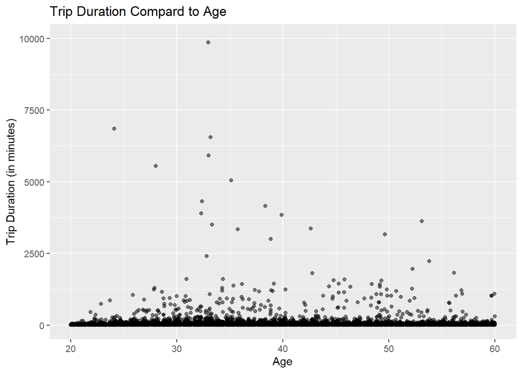

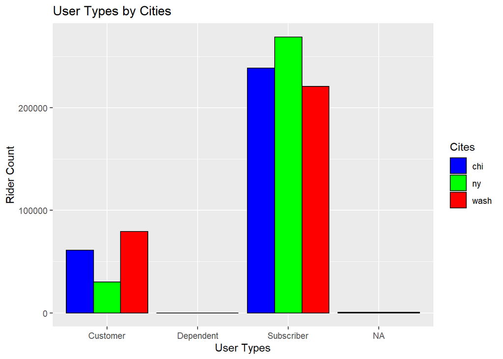

Note that Washington DC has the highest customer rate. This could be interesting to find out why and if you could incress the customer in New York, with out a decline on Subscribers.

# Multivariate Plots Section

Is there any interesting correlation between Age, Trip Duration and Gender?

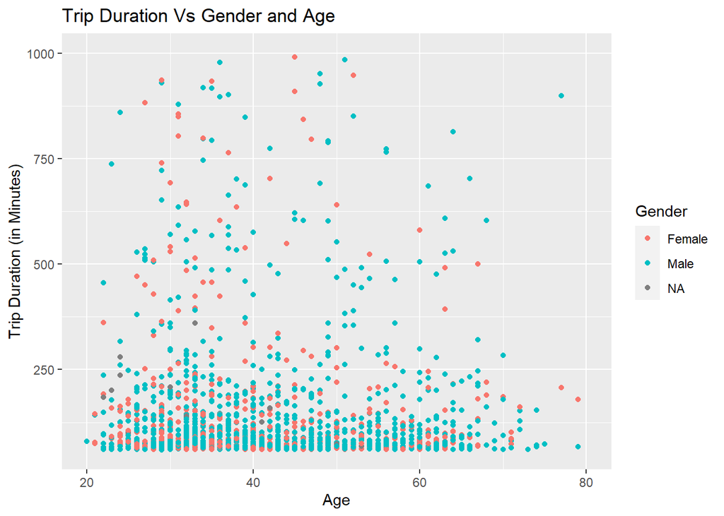

Age and Gender does not seem to have any change on the trip duration.

Let’s focus and only look at the females to see if there are any noticeable patterns

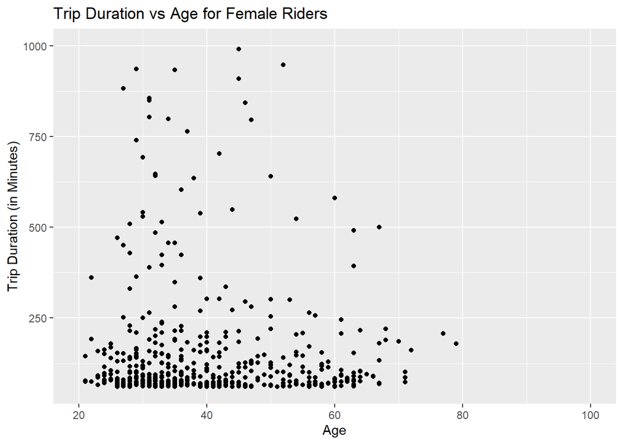

No real patterns jump out of the data when I removed the male and NA data.

Is there any interesting correlation between Age, Trip Duration and Cities?

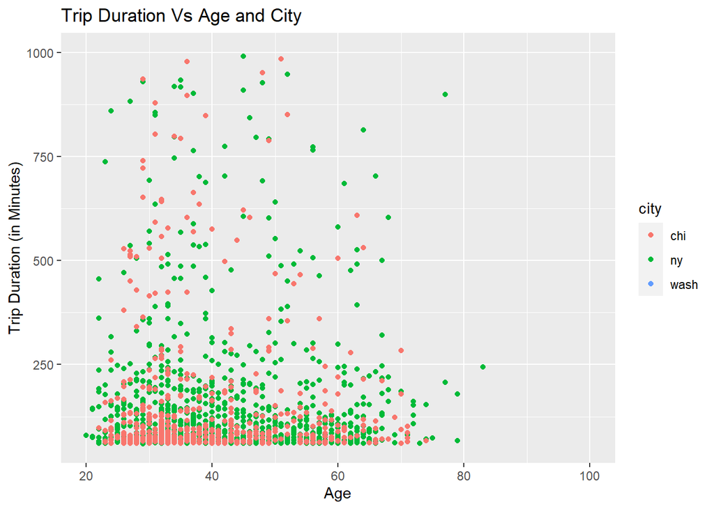

Cites don’t seem to play a large effect on the durarion of the trip. Yet, New Your does have te oldest riders.

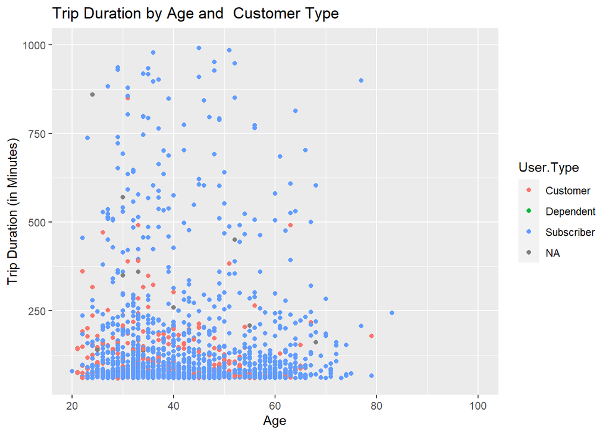

The customer type seem mostly to stay in short trips under 500 min. Where Subscriber’s have the longer trips. This seems to have the largest change on a riders duration.

# Multivariate Analysis

In this section of code, I was trying to see how gender, age, city, and subscriber type to see if we could figure out who the super users are. These are the outliers of trip distance.

The second chart shows that superusers are also most likely to be from New. York or Chicago. Though a little is more likely to be someone from New York.

In the third chart, unexpectedly supers users are subscribers.

If I were to go further with this analysis, I would be interested in adding some machine learning to be able to use this data to find a clear answer to this supper user. Also, I’d love to see more historical data so that I can make predictions on changes.As well as run some experimental campaigns and see if it changes the data at all.

# Final Plots and Summary

### Plot One

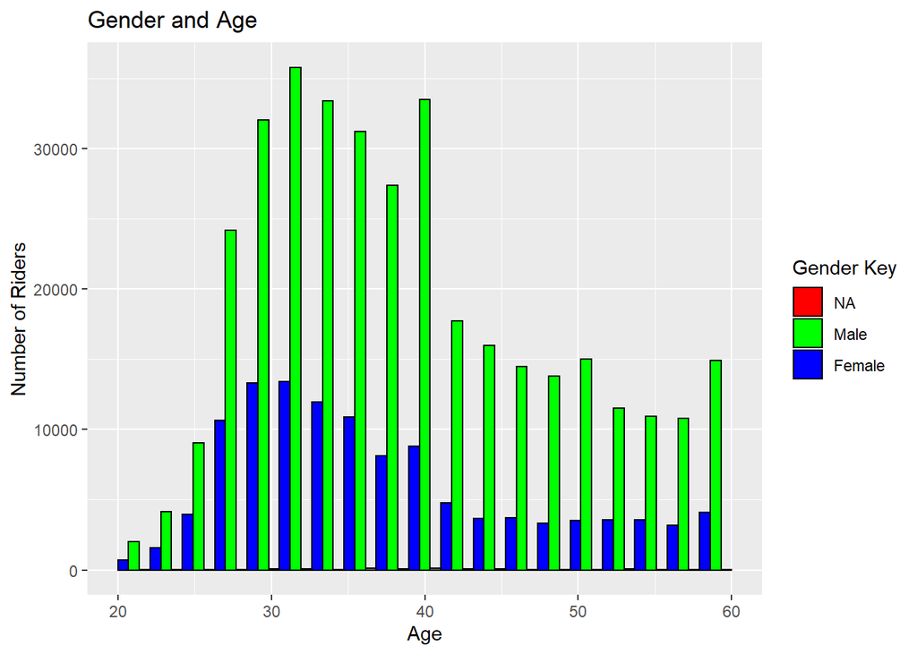

### Description One

This graph show gender vers age. While both graphs have the same shape the weight of having males be 64% of the users is really shown in this graph.

### Plot Two

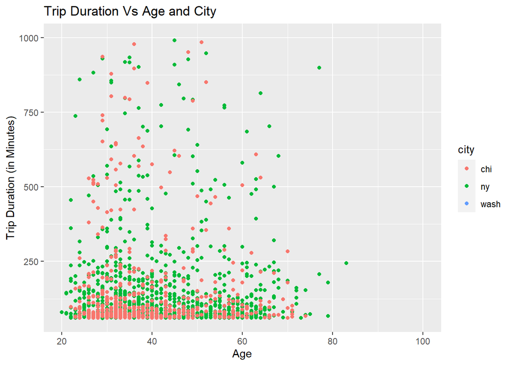

### Plot Three

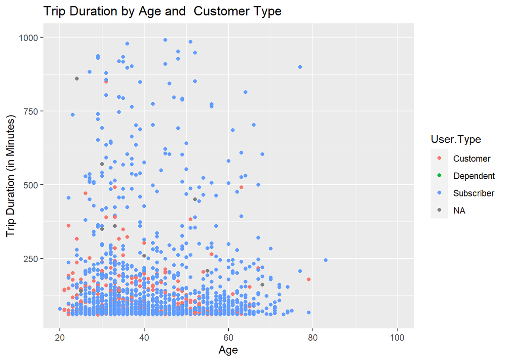

### Description Three

Here is a plot showing the age and trip Duration compared to User types. Looks like most of the long distance riders already have subscribtions.

# Reflection

In the first plot, we genuinely see the difference in male/female riders and the shape of age. The vast amount of customers that are male in the age of 30-35 shaped all other data points that we looked at in this analysis.

This data set was clean and promising at first. I think the biggest struggle I came to was wishing I had more data. The Washington D.C. data had no gender data, which left me feeling like I was missing a large piece of my puzzle. Also, the data set did not tell me the show was repeat customers. So while, in final chart # 3 it seems like there is a lot of long distant riders they could be a lot of repeat customers.